# Rain forecast

Shipeng Wang

August 16, 2019

# Introduction

### Topic

The main topic is the weather indicator given by the weather station in Australia. I am very interested in this. Since ancient times, we hope to make a prediction about the weather. In the past, we predicted whether it would rain on the second day by observing the color of the twilight weather and the thickness of the clouds. Now we are able to quantify the weather so we can make predictions more accurately.

### Dataset

Observations were drawn from numerous weather stations. The daily observations are available from http://www.bom.gov.au/climate/data. Copyright Commonwealth of Australia 2010, Bureau of Meteorology.

Link: https://www.kaggle.com/jsphyg/weather-dataset-rattle-package

### Goal

The main goal is to answer whether it will rain the next day, or what the probability of rain. By analyzing the weather indicators of the day, we need to find data related to whether it rains or not, and then build appropriate models among them to predict the weather of the next day.

### Variable

| Variable | Type | Unit | Meaning |
| --- | --- | --- | --- |
| Date | Continuous | Day | The date of observation |
| MinTemp | Continuous | Degrees celsius | The minimum temperature in degrees celsius |
| MaxTemp | Continuous | Degrees celsius | The maximum temperature in degrees celsius |
| Rainfall | Continuous | mm | The amount of rainfall recorded for the day in mm |
| Evaporation | Continuous | mm | The so-called Class A pan evaporation (mm) in the 24 hours to 9am |
| Sunshine | Continuous | Hour | The number of hours of bright sunshine in the day |
| WindGustSpeed | Continuous | km/h | The speed (km/h) of the strongest wind gust in the 24 hours to midnight |
| WindSpeed9am | Continuous | km/hr | Wind speed (km/hr) averaged over 10 minutes prior to 9am |
| WindSpeed3pm | Continuous | km/hr | Wind speed (km/hr) averaged over 10 minutes prior to 3pm |
| Humidity9am | Continuous | Percent | Humidity (percent) at 9am |
| Humidity3pm | Continuous | Percent | Humidity (percent) at 3pm |
| Pressure9am | Continuous | hpa | Atmospheric pressure (hpa) reduced to mean sea level at 9am |
| Pressure3pm | Continuous | hpa | Atmospheric pressure (hpa) reduced to mean sea level at 3pm |
| Cloud9am | Continuous | oktas | Fraction of sky obscured by cloud at 9am |
| Cloud3pm | Continuous | oktas | Fraction of sky obscured by cloud at 9am |
| Temp9am | Continuous | Degrees celsius | Temperature (degrees C) at 9am |

### Preperation

In this section I need to import the data and all the packages I need to use.

```r
data <- read.csv('/Users/wong/Downloads/weatherAUS.csv')

library(tidyverse)
library(gridExtra)
library(MASS)
require(scatterplot3d)
library(InformationValue)
library(ggplot2)
require(GGally)

head(data)
```

```
##         Date Location MinTemp MaxTemp Rainfall Evaporation Sunshine
## 1 2008-12-01   Albury    13.4    22.9      0.6          NA       NA
## 2 2008-12-02   Albury     7.4    25.1      0.0          NA       NA
## 3 2008-12-03   Albury    12.9    25.7      0.0          NA       NA
## 4 2008-12-04   Albury     9.2    28.0      0.0          NA       NA
## 5 2008-12-05   Albury    17.5    32.3      1.0          NA       NA
## 6 2008-12-06   Albury    14.6    29.7      0.2          NA       NA
##   WindGustDir WindGustSpeed WindDir9am WindDir3pm WindSpeed9am
## 1           W            44          W        WNW           20
## 2         WNW            44        NNW        WSW            4
## 3         WSW            46          W        WSW           19
## 4          NE            24         SE          E           11
## 5           W            41        ENE         NW            7
## 6         WNW            56          W          W           19
##   WindSpeed3pm Humidity9am Humidity3pm Pressure9am Pressure3pm Cloud9am
## 1           24          71          22      1007.7      1007.1        8
## 2           22          44          25      1010.6      1007.8       NA
## 3           26          38          30      1007.6      1008.7       NA
## 4            9          45          16      1017.6      1012.8       NA
## 5           20          82          33      1010.8      1006.0        7
## 6           24          55          23      1009.2      1005.4       NA
##   Cloud3pm Temp9am Temp3pm RainToday RISK_MM RainTomorrow
## 1       NA    16.9    21.8        No     0.0           No
## 2       NA    17.2    24.3        No     0.0           No
## 3        2    21.0    23.2        No     0.0           No
## 4       NA    18.1    26.5        No     1.0           No
## 5        8    17.8    29.7        No     0.2           No
## 6       NA    20.6    28.9        No     0.0           No
```

From the beginning of the data we can see the structure and information of the data set, and then I need to present the specific data content.

# Feature engineering

The first step is to think about which columns to keep as the predictive variables that we put into the model. I decide to use “MinTemp”“,”MaxTemp“,”Humidity9am“,”Humidity3pm“,”Pressure9am" and “Pressure3pm” as predictor variables, and “RainTomorrow” as target variable.

If it rains the next day, the clouds will accumulate in advance, and the temperature and air pressure will decrease significantly as the clouds thicken, so I used temperature and pressure as my predictor variables. The reason I choose humidity is when the clouds accumulate, because the sunshine is reduced, so the humidity in the air will increase appropriately, so I think the humidity can also help us to predict whether it will rain the next day.

So I need to put my chosen variables into the new data set.

```r
data <- data[,c(3,4,14,15,16,17,24)]
```

Then we need to look at the structure and content of the new data set.

```r
head(data)
```

```
##   MinTemp MaxTemp Humidity9am Humidity3pm Pressure9am Pressure3pm
## 1    13.4    22.9          71          22      1007.7      1007.1
## 2     7.4    25.1          44          25      1010.6      1007.8
## 3    12.9    25.7          38          30      1007.6      1008.7
## 4     9.2    28.0          45          16      1017.6      1012.8
## 5    17.5    32.3          82          33      1010.8      1006.0
## 6    14.6    29.7          55          23      1009.2      1005.4
##   RainTomorrow
## 1           No
## 2           No
## 3           No
## 4           No
## 5           No
## 6           No
```

```r
nrow(data)
```

```
## [1] 142193
```

```r
ncol(data)
```

```
## [1] 7
```

As we can see, there are 142193 rows and 7 columns in this data.

From the result below, we can look at the types and structure of each column.

```r
str(data)
```

```
## 'data.frame':    142193 obs. of  7 variables:
##  $ MinTemp     : num  13.4 7.4 12.9 9.2 17.5 14.6 14.3 7.7 9.7 13.1 ...
##  $ MaxTemp     : num  22.9 25.1 25.7 28 32.3 29.7 25 26.7 31.9 30.1 ...
##  $ Humidity9am : int  71 44 38 45 82 55 49 48 42 58 ...
##  $ Humidity3pm : int  22 25 30 16 33 23 19 19 9 27 ...
##  $ Pressure9am : num  1008 1011 1008 1018 1011 ...
##  $ Pressure3pm : num  1007 1008 1009 1013 1006 ...
##  $ RainTomorrow: Factor w/ 2 levels "No","Yes": 1 1 1 1 1 1 1 1 2 1 ...
```

And then we can view numercial summaries of continuous columns.

```r
summary(data)
```

```
##     MinTemp         MaxTemp       Humidity9am      Humidity3pm
##  Min.   :-8.50   Min.   :-4.80   Min.   :  0.00   Min.   :  0.00
##  1st Qu.: 7.60   1st Qu.:17.90   1st Qu.: 57.00   1st Qu.: 37.00
##  Median :12.00   Median :22.60   Median : 70.00   Median : 52.00
##  Mean   :12.19   Mean   :23.23   Mean   : 68.84   Mean   : 51.48
##  3rd Qu.:16.80   3rd Qu.:28.20   3rd Qu.: 83.00   3rd Qu.: 66.00
##  Max.   :33.90   Max.   :48.10   Max.   :100.00   Max.   :100.00
##  NA's   :637     NA's   :322     NA's   :1774     NA's   :3610
##   Pressure9am      Pressure3pm     RainTomorrow
##  Min.   : 980.5   Min.   : 977.1   No :110316
##  1st Qu.:1012.9   1st Qu.:1010.4   Yes: 31877
##  Median :1017.6   Median :1015.2
##  Mean   :1017.7   Mean   :1015.3
##  3rd Qu.:1022.4   3rd Qu.:1020.0
##  Max.   :1041.0   Max.   :1039.6
##  NA's   :14014    NA's   :13981
```

Last we need to check the missing values in each column.

```r
colSums(is.na(data))
```

```
##      MinTemp      MaxTemp  Humidity9am  Humidity3pm  Pressure9am
##          637          322         1774         3610        14014
##  Pressure3pm RainTomorrow
##        13981            0
```

# Single variable plots

From the result, we can see that there are a lot of missing value in this data, therefore, we need to deal with the missing value, so that the data can be better analyzed by us. Before the cleaning, I want to show the frequency of each variable.

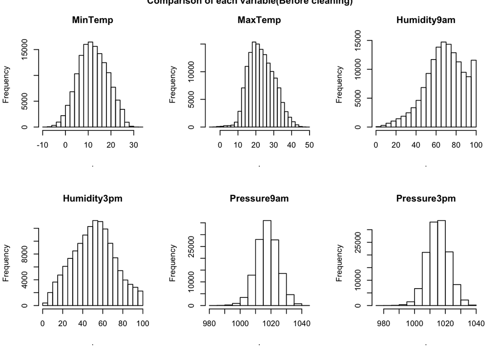

```r
par(mfrow=c(2,3))
data$MinTemp %>% hist(main='MinTemp')
data$MaxTemp %>% hist(main='MaxTemp')
data$Humidity9am %>% hist(main='Humidity9am')
data$Humidity3pm %>% hist(main='Humidity3pm')
data$Pressure9am %>% hist(main='Pressure9am')
data$Pressure3pm %>% hist(main='Pressure3pm')
title(main = 'Comparison of each variable(Before cleaning)', outer=TRUE)
```

This is a single plot that shows the frequency of all the variables before the cleaning.

We need to clean the data next.

```r
data$MinTemp <- data$MinTemp %>%
  replace_na(median(data$MinTemp, na.rm=TRUE))
data$MaxTemp <- data$MaxTemp %>%
  replace_na(median(data$MaxTemp, na.rm=TRUE))
data$Humidity9am <- data$Humidity9am %>%
  replace_na(median(data$Humidity9am, na.rm=TRUE))
data$Humidity3pm <- data$Humidity3pm %>%
  replace_na(median(data$Humidity3pm, na.rm=TRUE))
data$Pressure9am <- data$Pressure9am %>%
  replace_na(median(data$Pressure9am, na.rm=TRUE))
data$Pressure3pm <- data$Pressure3pm %>%
  replace_na(median(data$Pressure3pm, na.rm=TRUE))
```

Then I check the missing data and make the frequency plot again.

```r
colSums(is.na(data))
```

```
##      MinTemp      MaxTemp  Humidity9am  Humidity3pm  Pressure9am
##            0            0            0            0            0
##  Pressure3pm RainTomorrow
##            0            0
```

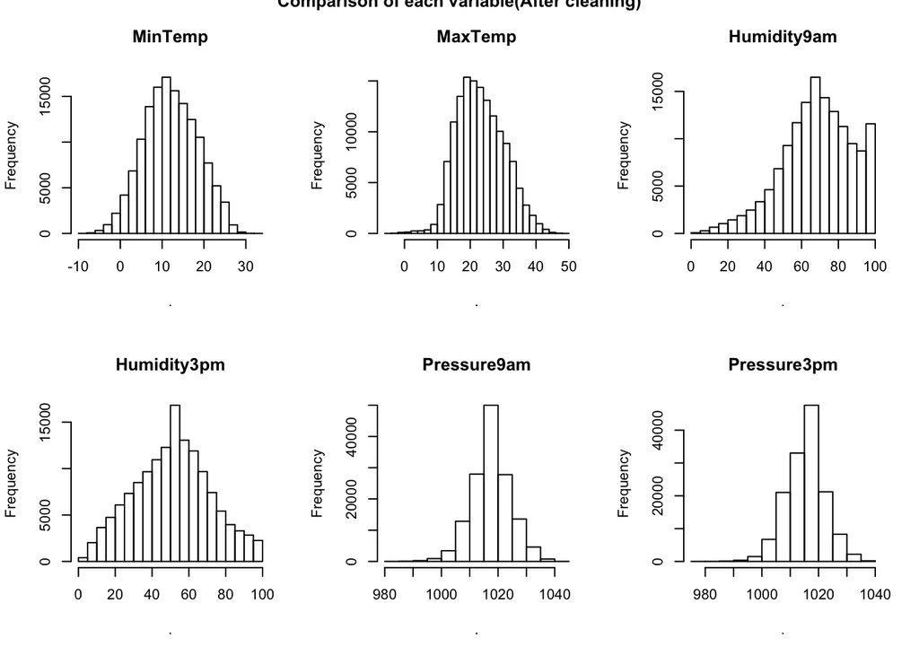

```r
par(mfrow=c(2,3))
data$MinTemp %>% hist(main='MinTemp')
data$MaxTemp %>% hist(main='MaxTemp')
data$Humidity9am %>% hist(main='Humidity9am')
data$Humidity3pm %>% hist(main='Humidity3pm')
data$Pressure9am %>% hist(main='Pressure9am')
data$Pressure3pm %>% hist(main='Pressure3pm')
title(main = 'Comparison of each variable(After cleaning)', outer=TRUE)
```

After I have cleaned up all the predictor variables, I need to clean up the only target variable (RainTomorrow).

```r
levels(data$RainTomorrow)
```

```
## [1] "No"  "Yes"
```

```r
table(data$RainTomorrow)
```

```
##
##     No    Yes
## 110316  31877
```

As we can see, there are two levels in this column, which are “No” and “Yes”. I want to change them into “0” and “1”.

```r
levels(data$RainTomorrow)[1] <- "0"
levels(data$RainTomorrow)[2] <- "1"
levels(data$RainTomorrow)
```

```
## [1] "0" "1"
```

```r
table(data$RainTomorrow)
```

```
##
##      0      1
## 110316  31877
```

Above, I have finished all the previous data cleaning work. All the variables I need to use do not include missing value, all the continuous variables show approximate normal distribution, and all the categorical variables have reduced to meaningful categoriess.

# Multiple variable plots

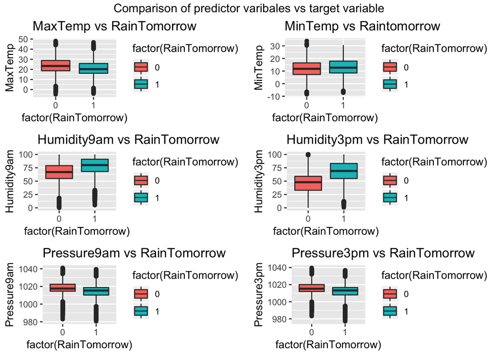

```r
p_MaxTemp <- data %>% ggplot(aes(y=MaxTemp,
                               x=factor(RainTomorrow),
                               fill=factor(RainTomorrow))) +
  geom_boxplot() + labs(title = "MaxTemp vs RainTomorrow")

p_MinTemp <- data %>% ggplot(aes(y=MinTemp,
                               x=factor(RainTomorrow),
                               fill=factor(RainTomorrow))) +
  geom_boxplot() + labs(title = "MinTemp vs Raintomorrow")

p_Humidity9am <- data %>% ggplot(aes(y=Humidity9am,
                                   x=factor(RainTomorrow),
                                   fill=factor(RainTomorrow))) +
  geom_boxplot() + labs(title = "Humidity9am vs RainTomorrow")

p_Humidity3pm <- data %>% ggplot(aes(y=Humidity3pm,
                                   x=factor(RainTomorrow),
                                   fill=factor(RainTomorrow))) +
  geom_boxplot() + labs(title = "Humidity3pm vs RainTomorrow")

p_Pressure9am <- data %>% ggplot(aes(y=Pressure9am,
                                   x=factor(RainTomorrow),
                                   fill=factor(RainTomorrow))) +
  geom_boxplot() + labs(title = "Pressure9am vs RainTomorrow")

p_Pressure3pm <- data %>% ggplot(aes(y=Pressure3pm,
                                   x=factor(RainTomorrow),
                                   fill=factor(RainTomorrow))) +
  geom_boxplot() + labs(title = "Pressure3pm vs RainTomorrow")

grid.arrange(p_MaxTemp, p_MinTemp, p_Humidity9am, p_Humidity3pm,
             p_Pressure9am, p_Pressure3pm, ncol=2, top='Comparison of predictor varibales vs target variable')
```

Then I use “pair” plot to show the correlation between each variable.

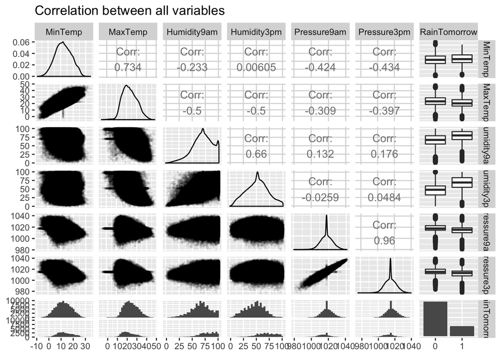

```r
lower = list(continuous = wrap(ggally_points, size = 0.5, alpha=0.05))
ggpairs(data, columns=1:6:ncol(data), title='Correlation between all variables',
        lower=lower)
```

I used “pairs” plots to show the relationship between all variables. Although each plot was reduced to a very small size, it is worth noting that we can still see a strong linear relationship between some variables in the plot, such as MinTemp and MaxTemp. We can see from the correlation coefficient that some variables are very similar, such as the correlation coefficient of MinTemp and MaxTemp is 0.73, and the correlation coefficient of Pressure3Pm and Pressure9am is 0.96.

I cannot give the prediction variables I need to give up from the plot, so I choose to use PCA to help me reduce the dimension of data.

### PCA

Applying PCA using R funcion:

```r
df <- data[,c(1,2,3,4,5,6)]
pca <- prcomp(df)
pca
```

```
## Standard deviations (1, .., p=6):
## [1] 25.818094 12.246314  9.696659  6.606109  2.431706  1.187838
##
## Rotation (n x k) = (6 x 6):
##                     PC1        PC2        PC3        PC4         PC5
## MinTemp     -0.03897222 -0.3071160 -0.3035641 0.57052555  0.68372194
## MaxTemp     -0.16248603 -0.1632366 -0.3574843 0.56946635 -0.68056125
## Humidity9am  0.65532453  0.5811239 -0.4754310 0.07977009  0.02107236
## Humidity3pm  0.73530090 -0.5950646  0.2888068 0.05180633 -0.13769535
## Pressure9am  0.02120669  0.3140671  0.4771485 0.43435216 -0.14566860
## Pressure3pm  0.03888549  0.2976382  0.4928886 0.39051212  0.16952077
##                      PC6
## MinTemp     -0.137966326
## MaxTemp      0.178049374
## Humidity9am  0.001669905
## Humidity3pm  0.013319816
## Pressure9am -0.680705715
## Pressure3pm  0.696938475
```

The result returns 6 principal components as rotation.

Next step is to identify coverage of variance in dataset by individual principal components.

```r
summary(pca)
```

```
## Importance of components:
##                            PC1     PC2     PC3     PC4     PC5     PC6
## Standard deviation     25.8181 12.2463 9.69666 6.60611 2.43171 1.18784
## Proportion of Variance  0.6932  0.1560 0.09779 0.04539 0.00615 0.00147
## Cumulative Proportion   0.6932  0.8492 0.94700 0.99238 0.99853 1.00000
```

We can see from the result that PC1 can explain 69.32% of variance and PC2 can explain 15.60%. The cumulative proportion of PC3 is 94.70% of variance, so we can use 3 principle components for this analysis.

In addition, I also made scree plot to help us choose the number of PC better.

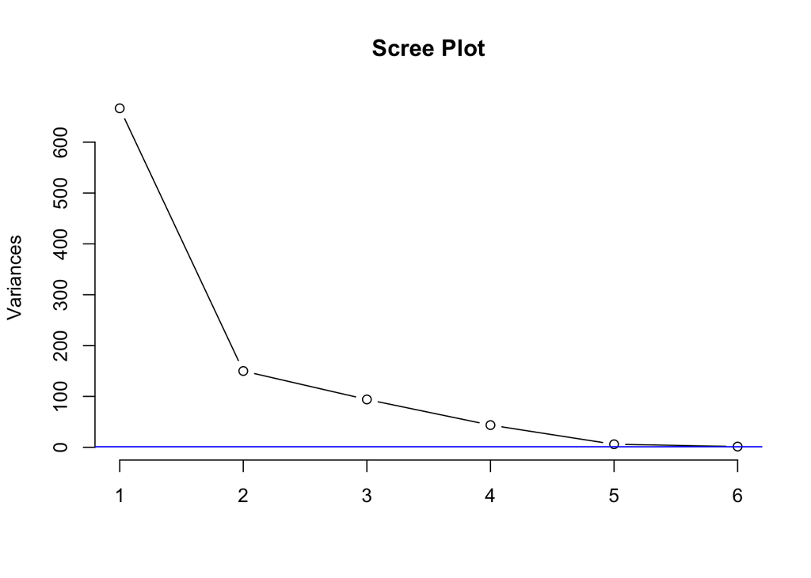

```r
plot(pca,
     type="line",
     main="Scree Plot")
abline(h=1,col="blue")
```

In Scree plot, we can find that after the two PCs, the steps tend to be the same, so for this analysis, we can use two or three PCs for dimension reduction.

Here I try out three PCS for analysis.

```r
PC_df <- pca$x[,1:3]
PC_df <- as.data.frame(PC_df)
PC_df <- cbind(RainTomorrow = data$RainTomorrow, PC_df)
head(PC_df)
```

```
##   RainTomorrow        PC1        PC2         PC3
## 1            0 -20.807143  12.925669 -18.5543350
## 2            0 -36.329920  -1.947155  -2.0876066
## 3            0 -36.925824 -10.870628  -0.6629259
## 4            0 -42.490788   6.650017  -0.9409352
## 5            0  -7.174452  10.624928 -24.2751832
## 6            0 -31.743002   1.519189 -13.5759904
```

Then I calculated the first, second and third principal components for each day, and I add “RainTomorrow” into this dataframe to help me plot.

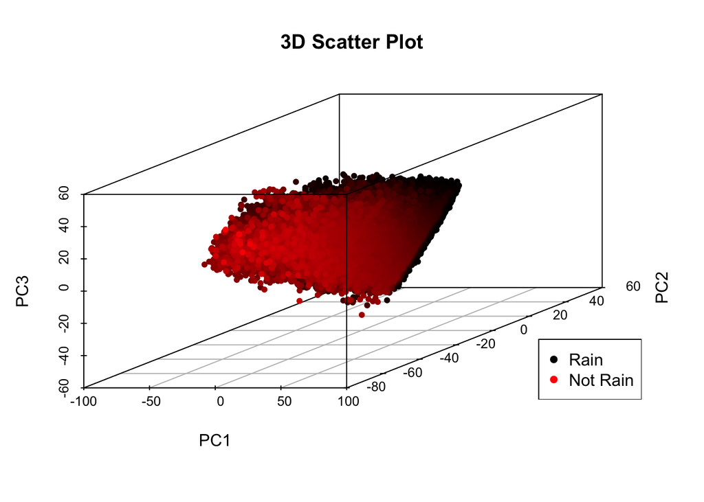

```r
plot <- scatterplot3d(PC_df[,2:4], pch=20, highlight.3d=TRUE,
                      main="3D Scatter Plot")
legend("bottomright", legend=c("Rain","Not Rain"), col=c(1,2), pch=16)
```

# Modeling

### 3 PCs

I choose to use logistic regression to predict the probability of RainTomorrow. First, I divided the data set into two parts. 80% of the data were randomly divided into train sets, while the remaining 20% of the data were test sets.

```r
set.seed(1)
row.number <- sample(x=1:nrow(PC_df), size=0.8*nrow(PC_df))
train = PC_df[row.number,]
test = PC_df[-row.number,]
```

Then I built the logistic regression model and trained it with the train set. The results are as follows.

```r
logistic_model <- glm(RainTomorrow ~ PC1+PC2+PC3, family=binomial(link="logit"), data=train)
summary(logistic_model)
```

```
##
## Call:
## glm(formula = RainTomorrow ~ PC1 + PC2 + PC3, family = binomial(link = "logit"),
##     data = train)
##
## Deviance Residuals:
##     Min       1Q   Median       3Q      Max
## -2.3162  -0.6366  -0.3762  -0.1644   3.2140
##
## Coefficients:
##               Estimate Std. Error z value Pr(>|z|)
## (Intercept) -1.7134165  0.0100355 -170.74   <2e-16 ***
## PC1          0.0471024  0.0004092  115.12   <2e-16 ***
## PC2         -0.0613615  0.0007166  -85.63   <2e-16 ***
## PC3         -0.0299093  0.0008609  -34.74   <2e-16 ***
## ---
## Signif. codes:  0 '***' 0.001 '**' 0.01 '*' 0.05 '.' 0.1 ' ' 1
##
## (Dispersion parameter for binomial family taken to be 1)
##
##     Null deviance: 121032  on 113753  degrees of freedom
## Residual deviance:  91675  on 113750  degrees of freedom
## AIC: 91683
##
## Number of Fisher Scoring iterations: 5
```

From the result we can see:

1: All the P-values of three components are small, so all the components have a significant correlation with the target variable.

In the result we can see the model’s prediction of the probability of rain. If it is greater than 0.5, then I set it to 1, and the other data is set to 0.

```r
pred <- predict(logistic_model, newdata = test, type = "response")

y_pred_num <- ifelse(pred > 0.5, 1, 0)
y_predicted <- factor(y_pred_num, levels=c(0, 1))
y_observed <- test$RainTomorrow
```

For this part I put the Confusion matrix to help me calculate the accuracy of this model.

```r
ct_3PCs = table (y_predicted, y_observed)
ct_3PCs
```

```
##            y_observed
## y_predicted     0     1
##           0 20913  3851
##           1  1136  2539
```

And then I calculate the Precision, Recall and F1 Score of this 3PCs model.

```r
Precision_3PC = 20926 / (20926+3932)
Recall_3PC = 20926 / (20926+1123)
F1_Score_3PC = 2*Precision_3PC*Recall_3PC/(Precision_3PC+Recall_3PC)
Precision_3PC
```

```
## [1] 0.8418215
```

```r
Recall_3PC
```

```
## [1] 0.949068
```

```r
F1_Score_3PC
```

```
## [1] 0.8922336
```

As we can see, the Precision is 0.84, which means that if the model predicts that it will not rain the next day, the accuracy rate will reach 84.18%.

The Recall is 0.94, which means that if it will not rain the next day, the probability that the model give the correct predictive is 94.90%.

F1 Score is Harmonic mean, this is kind of an average when x and y are equal. But when x and y are different, then it’s closer to the smaller number as compared to the larger number. It makes more sense for us to measure the accuracy of the model. As we can see, the F1 Score is 0.89, it is a really high score, which means that the model that have 3 PCs can explain 89.22% of the data.

Next I will take 2 PCs into model to compare with the result of 3 PCs.

### 2 PCs

```r
PC_df_2 <- PC_df[,c(1,2,3)]

set.seed(2)
row.number <- sample(x=1:nrow(PC_df), size=0.8*nrow(PC_df_2))
train_2 = PC_df_2[row.number,]
test_2 = PC_df_2[-row.number,]

logistic_model_2 <- glm(RainTomorrow ~ PC1+PC2, family=binomial(link="logit"), data=train_2)

pred_2 <- predict(logistic_model_2, newdata = test_2, type = "response")

y_pred_num_2 <- ifelse(pred_2 > 0.5, 1, 0)
y_predicted_2 <- factor(y_pred_num_2, levels=c(0, 1))
y_observed_2 <- test_2$RainTomorrow

ct_2PCs = table (y_predicted_2, y_observed_2)
ct_2PCs
```

```
##              y_observed_2
## y_predicted_2     0     1
##             0 21031  3811
##             1  1092  2505
```

```r
Precision_2PC = 21024 / (21024+3882)
Recall_2PC = 21024 / (21024+1099)
F1_Score_2PC = 2*Precision_3PC*Recall_3PC/(Precision_3PC+Recall_3PC)
Precision_2PC
```

```
## [1] 0.8441339
```

```r
Recall_2PC
```

```
## [1] 0.9503232
```

```r
F1_Score_2PC
```

```
## [1] 0.8922336
```

Similar explaination with 3PCs, if the model predicts that it will not rain the next day, the accuracy rate will reach 84.41%.

The Recall is 0.95, which means that if it will not rain the next day, the probability that the model give the correct predictive is 95.03%.

Next I’ll put the original data (no PC) into the model to check the accuracy.

### No PC

```r
set.seed(3)
row.number <- sample(x=1:nrow(data), size=0.8*nrow(data))
train_3 = data[row.number,]
test_3 = data[-row.number,]

logistic_model_3 <- glm(RainTomorrow ~ MinTemp + MaxTemp + Humidity3pm +
                          Humidity9am + Pressure3pm + Pressure9am,
                        family=binomial(link="logit"), data=train_3)

pred_3 <- predict(logistic_model_3, newdata = test_3, type = "response")

y_pred_num_3 <- ifelse(pred_2 > 0.5, 1, 0)
y_predicted_3 <- factor(y_pred_num_2, levels=c(0, 1))
y_observed_3 <- test_3$RainTomorrow

ct_3PCs = table (y_predicted_3, y_observed_3)
ct_3PCs
```

```
##              y_observed_3
## y_predicted_3     0     1
##             0 19383  5459
##             1  2724   873
```

```r
Precision_0PC = 19421  / (19421 +5485)
Recall_0PC = 19421  / (19421 +2686)
F1_Score_0PC = 2*Precision_0PC*Recall_0PC/(Precision_0PC+Recall_0PC)
Precision_0PC
```

```
## [1] 0.7797719
```

```r
Recall_0PC
```

```
## [1] 0.8785
```

```r
F1_Score_0PC
```

```
## [1] 0.826197
```

The precision is 0.78, if the model predicts that it will not rain the next day, the accuracy rate will reach 77.98%.

The Recall is 0.88, which means that if it will not rain the next day, the probability that the model give the correct predictive is 87.85%.

F1 Score is 0.83, which means that the model can explain 82.61% of the data.

### Comparison

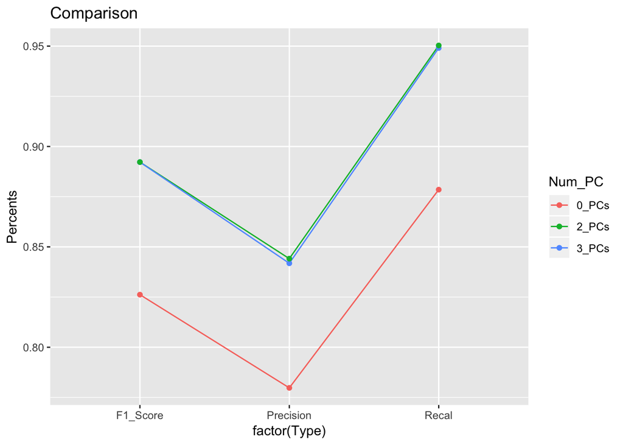

```r
Num_PC=c("3_PCs","3_PCs","3_PCs","2_PCs","2_PCs","2_PCs","0_PCs","0_PCs","0_PCs")
Type=c("Precision","Recal","F1_Score","Precision","Recal","F1_Score","Precision","Recal","F1_Score")
Percents=c(Precision_3PC,Recall_3PC,F1_Score_3PC,Precision_2PC,Recall_2PC,F1_Score_2PC,Precision_0PC,Recall_0PC,F1_Score_0PC)
df=data.frame(Num_PC,Type,Percents)
ggplot(df, aes(x=factor(Type), y=Percents, colour=Num_PC,group=Num_PC)) + geom_line() +geom_point() + labs(title="Comparison")
```

# Conclusions

3: Through the final accuracy comparison, the three models are not as good as the Recal on Precision. If I have more time, I will dig deeper into the data, find out the reasons and improve their Precision.